# TRAP: exposure prediction with mobile monitoring data

Si Cheng

2020-12-10

## Problems from last time

In our last meeting (11/12) we discussed prediction models for PM2.5 (previously done by Travis). There were two main questions left for investigation and here are my findings:

- There was a gap in reproduced CV error of UK-PLS from the original analysis – I obtained 0.68 (5-fold CV) while Travis obtained 0.73 (10-fold CV). Changing from 5-fold CV to 10-fold, my result became 0.75, which was close to the original one.
- Details about the two variable importance measures for spatial random forest:
  - Accuracy lost by permuting the values of each predictor (which I used last time)
  - Accuracy gain from splits based on each predictor (which I did not use)

## Summary

I completed the pre-processing of geocovariates, which results in 183 predictors in total. My pre-processing was slightly different from the original analysis of the group – the group used both the mobile monitoring (MM) data and the ACT cohort data, while I only have access to the MM data (I checked with Amanda that only MM data is needed for the Aim that we are working with).

Prediction models were built for two pollutants – ultrafine particles (UFP) and black carbon (BC), and investigated two versions of annual averages for each of them – the simple unweighted annual average and the adjusted one (regression estimates adjusted for season-, time-of-week- and time-of-day). Models were based on the log-transformed annual averages.

5-fold cross-validation (CV) was conducted to compare the accuracy of UK-PLS and two spatial random forest models. Accuracy of each model (along with the original UK-PLS model done by the group) was summarized below by $R^2$.

I selected the following parameters of spatial random forest by random search within a given range:

- Number of covariates to sample for each tree
- Minimum leaf size (and in turn, the maximum number of leaves to use)
- Number of observations to use in each tree

[output not shown]

The accuracy of UK-PLS was close to the original results.

The figure below shows a comparison of prediction error of different models. The first column are the observed pollutant concentrations (log scale), and the remaining 3 columns show CV errors.

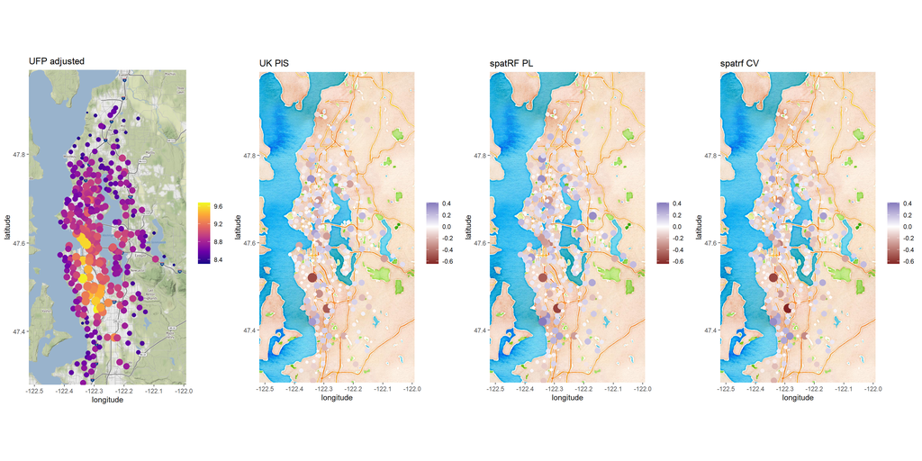

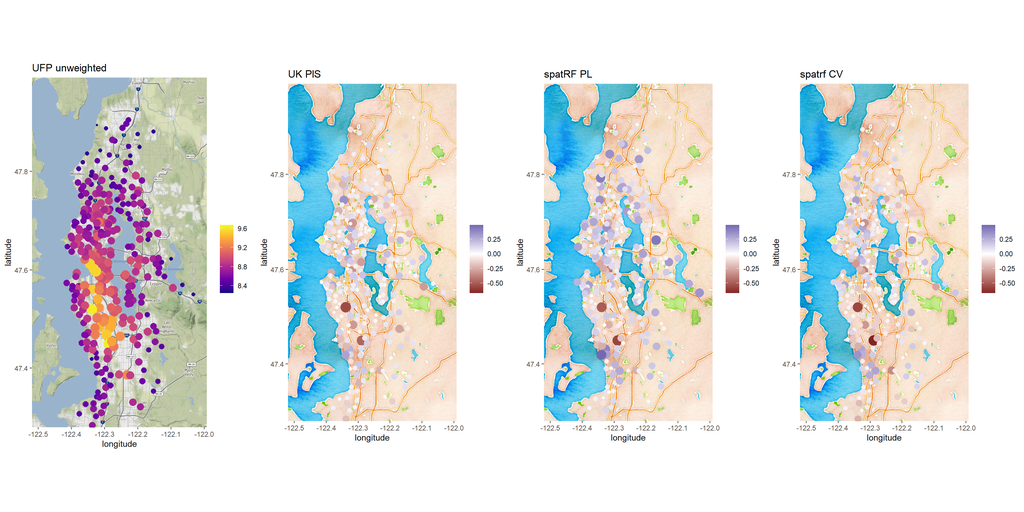

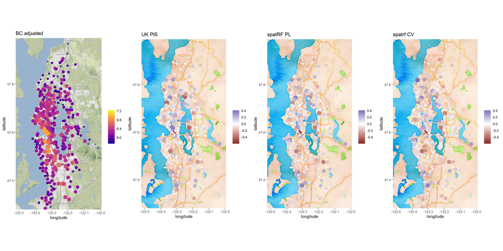

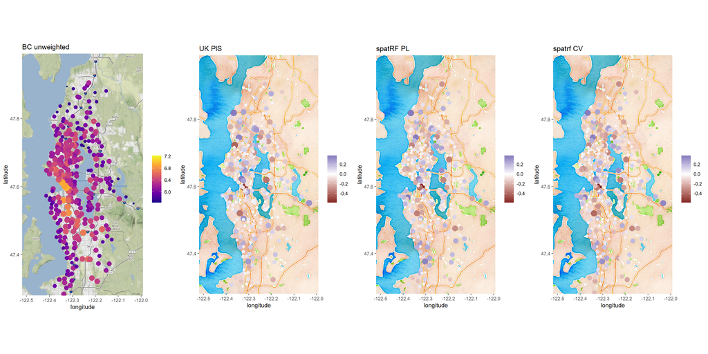

## Variable importance

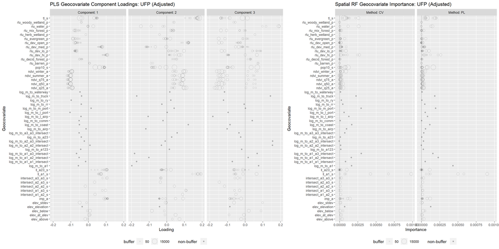

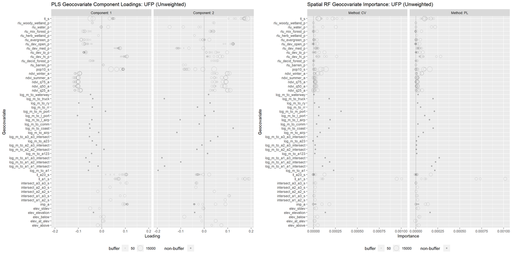

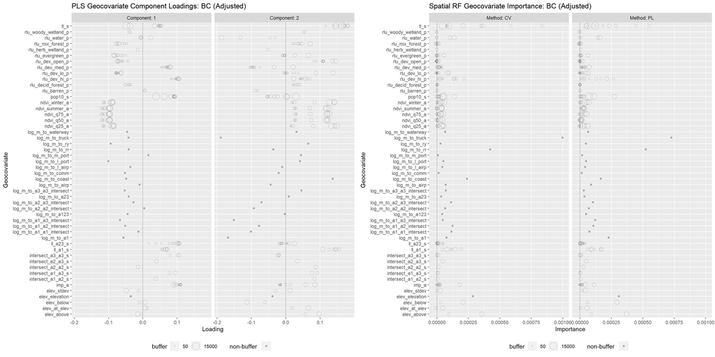

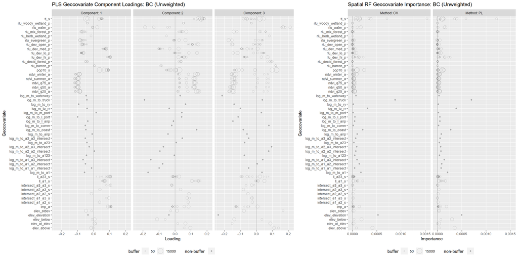

## Next steps

- Fine-tune the spatial RFs further to see whether better model performance can be attained